# Manual Git

Fernando

2023-08-15

# Git

[figure not shown]

## ¿Qué es Git?

Es un sistema controlador de versiones *(VCS)*, es decir, registra y da seguimiento a los cambios (y quién los realiza) de los archivos de un proyecto a lo largo del tiempo.

Su importancia radica en que tenemos a nuestra disposición el historial de cambios desde el inicio hasta el estado actual del proyecto. Esto implica que se puede regresar a cualquier versión del proyecto, retomar código y archivos pasados, trabajar en nuevas versiones sin afectar al resto y en particular sin afectar a la versión estable de nuestro proyecto dado que a veces se tienen que probar varias alternativas antes de llegar a una solución estable. Las versiones son estas múltiples alternativas y hacer un seguimiento de lo que se ha intentado es la forma más efectiva de obtener la mejor solución a nuestros requerimientos, arreglar errores, y trabajar en equipo de forma remota dando a cada colaborador una copia del repositorio, donde tienen acceso a cada parte del historial del proyecto, pueden crear ramas y realizar otras operaciones; lo que convierte a Git en un sistema de control de versiones distribuido.

Este tutorial pretende dejar las herramientas indispensables para trabajar un proyecto con Git.

## Instalación

Git está disponible en los tres sistemas operativos más comunes: *Windows, Mac, Linux/Unix*.

[figure not shown]

### Instalar Git en Windows

- Ir a la URL para iniciar la [descarga](https://git-scm.com/download/win) de Git para Windows.
- Descargar y comenzar ejecución.
- Asegurarse de seleccionar Git Bash Here cuando se llegue a la ventana de selección de componentes.

[figure not shown]

- Seguir con la instalación.

[figure not shown]

### Instalar Git en Mac

- Abrir terminal y escribir el siguiente comando: **git version** (en caso de que imprima la versión de git instalada omitir los siguientes pasos).
- Ir a la URL para iniciar la [descarga](https://git-scm.com/download/mac) de Git para Mac.
- Elegir una instalación de Git.

### Instalar Git en Linux/Unix

- Ir a la URL para iniciar la [descarga](https://git-scm.com/download/linux) de Git para Linux/Unix.
- La instalación se hará desde la ventana de terminal con la linea de comandos del administrador de paquetes de tu distribución de Linux.

**Nota**: *Para acceder a Git desde Windows se utilizará el Git BASH, mientras que para LINUX/Unix y MAC será por la terminal*.

## Conceptos VCS

- **Directory**: Es un contenedor en el que se almacenan archivos de datos y otros subdirectorios de forma organizada.
- **Repository**: Es un área de almacenamiento para los archivos. En el control de versiones es un directorio o carpeta que contiene todos los archivos del Proyecto en que se está trabajando.
- **Commit**: Es un cambio guardado. Hacer un commit es tomar registro dentro del repositorio de un cambio a algún o algunos archivos del proyecto.
- **Staging Area**: Es un área de preparación para agregar, eliminar, cambiar el nombre de los archivos, seleccionar y elegir exactamente qué partes de los cambios deben de estar en el repositorio. Es el área donde elegimos los cambios para hacer un commit.
- **Branch**: Es otro camino o línea de commits del desarrollo del repositorio. Crear ramas es hacer copias del repositorio que sirven para hacer cambios (arreglar errores, probar otras ideas, etc.) sin afectar al la rama principal.
- **Master Branch**: Cuando se inicia un repositorio, Git crea una rama predeterminada para el desarrollo del proyecto, esta es la rama principal y se llama rama Master.
- **HEAD**: Es la rama actual, en el commit actual de la rama.
- **Merge**: Es un commit que se crea de fusionar el trabajo de una rama con otra para incorporar el desarrollo del proyecto.
- **Clone**: Es una copia del respositorio que existe en algún lugar localmente o remotamente.

## Primeros pasos con Git

Hay dos tipos de comandos:

- Los comandos comunes que realizan operaciones típicas.
- Los proporcionados por Git

### Comandos comunes, operaciones típicas

Estos comandos no llevan una estructura en particular. Son por lo general los mismos comandos de consola o terminal.

#### Comandos comunes para directorios y archivos

- **pwd**: Imprime el directorio actual.
- **ls**: Enlista los archivos en el directorio actual.
- **mkdir** *directory_name* : Crea un directorio.
- **cd** *directory_name* : Cambia el directorio actual al directorio solicitado.
- **cd ..** : Cambia el directorio actual al directorio anterior.
- **touch**: Crea un archivo en el directorio actual.
- **cat**: Lee el contenido de texto de un archivo.
- **rm**: Elimina archivos del flujo del trabajo.
- **rm -r**: Elimina directorios del flujo de trabajo.
- **clear**: Borra toda la pantalla y nos deja un Git Bash o terminal limpio.

**Vemos el directorio actual y enlistamos los archivos contenidos. Como el directorio está vacío creamos dos carpetas y un archivo**

[figure not shown]

**Limpiamos el Git Bash o terminal según sea el caso con clear, y nos movemos al directorio Documents/Comandos/Carpeta01, creamos un archivo.txt y vemos el contenido del archivo**

[figure not shown]

**Regresamos al directorio anterior Documents/Comandos, enlistamos los archivos y eliminamos la carpeta02, podemos notar que si enlistamos de nuevo ya no imprime la carpeta**

[figure not shown]

**Limpiamos Git Bash, eliminamos Archivo01**

[figure not shown]

### Comandos proporcionados por Git

Todas las líneas de comando de Git van a seguir una misma convención: La palabra **git** seguida de **switches** opcionales, el **comando** y **argumentos** opcionales.

`git [switches] \<command\> [\<args\>]`

### Configuración inicial

Como Git da seguimiento a quién hizo algún cambio dentro del repositorio, es necesario configurar (personalizar) Git. Tendrás que abrir *Git Bash* o la *terminal* según sea el caso y escribir los siguientes comandos proporcionados por Git.

`git config --global user.name "Nombre"`

`git config --global user.email "Correo"`

**Nota**: *Es importante que el correo sea el mismo que el correo de GitHub*

Para poder ver todas las configuraciones:

`git config --list`

### Comandos comunmente usados en Git

- **help**: Obtiene ayuda sobre algún comando, abre la documentación de Git.
- **init**: Empieza un repositorio vacío o reinicia uno existente.
- **status**: Muestra el estatus del flujo de trabajo.
- **add**: Agrega archivos al staging area.
- **commit**: Guarda los cambios en el repositorio.
- **log**: Muestra una lista de los commits.
- **checkout**: Cambia de rama y de commit dentro del flujo de trabajo.
- **diff**: Muestra cambios en el flujo de trabajo.
- **rm**: Elimina archivos del flujo del trabajo.
- **branch**: Enlista, crea o elimina ramas.
- **merge**: Junta ramas en el desarrollo del repositorio.
- **reset**: Reestablece el repositorio al estado necesario.
- **remote**: Enlaza un repositorio local con un reposirotio remoto.
- **push**: Actualiza referencias remotas junto con objetos asociados.
- **clone**: Clona un repostorio en un nuevo directorio.
- **fetch**: Descarga objetos y referencias desde otro repositorio.
- **pull**: Comprime los comandos `fetch` y `merge`.

## Empezando con Git

### Ayuda en Git

#### `git help`

Cada comando tiene ayuda a la que puedes acceder, y aprender a acceder a ella permitirá ser más efectivo en Git. El sistema de ayuda de Git es donde se debe comenzar si buscas respuestas sobre Git, ya que tiene una descripción de cada comando disponible, junto con sus opciones y argumentos válidos, también contiene guías sobre cómo realizar tareas comunes de los desarrolladores de Git y un glosario.

Para obtener ayuda sobre la ayuda (`help`) de Git debemos escribir `git help help` en el Git Bash o Terminal

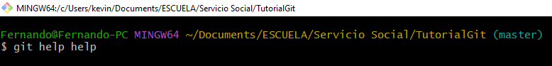

Git nos va a redirigir a una página *htlm* con la descripción del comando `help` y cómo usarlo.

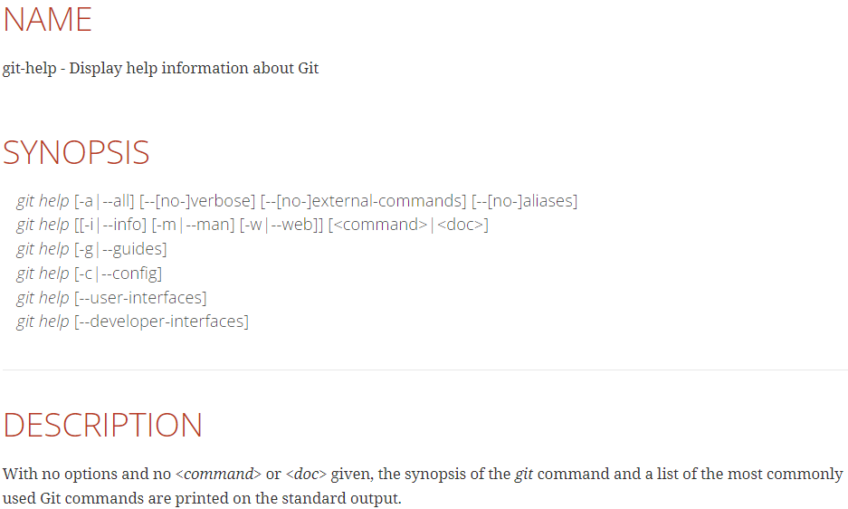

Esta herramienta nos va a ser de gran ayuda en cualquier momento que tengamos dudas sobre algún comando en Git.

### Iniciar un repositorio con Git

Para empezar con git es neceseario crear nuestro espacio de trabajo. El espacio desde el cuál estarémos dando seguimiento a cada parte del historial del proyecto.

En el directorio donde vamos a alojar nuestro proyecto debemos crear nuestro repositorio con el siguiente comando.

#### `git init`

Este comando nos creará dentro del directorio una carpeta `.git`, es decir, nuestro repositorio vacío.

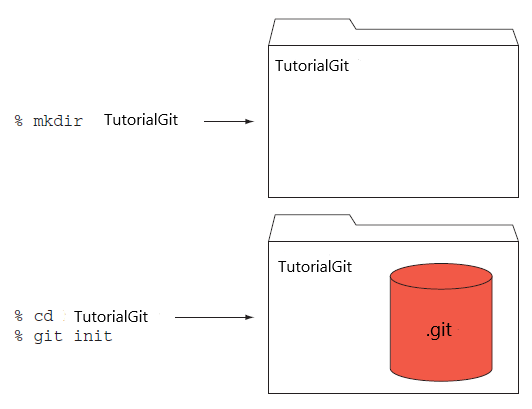

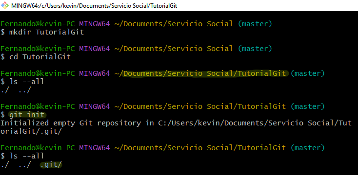

Una buena práctica en git es checar el estatus de nuestro repositorio.

#### `git status`

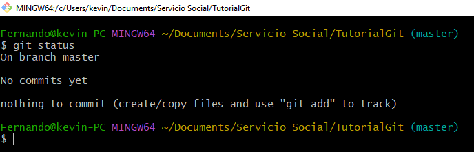

Nuestro `git status` nos muestra que estamos en nuestra *rama master*, que no tenemos commits y que no tenemos nada a qué hacerle commit. Esto tiene sentido dado que nuestro *working directory* está vacío. Vamos a crear un archivo README.md y agregarlo a nuestro repositorio.

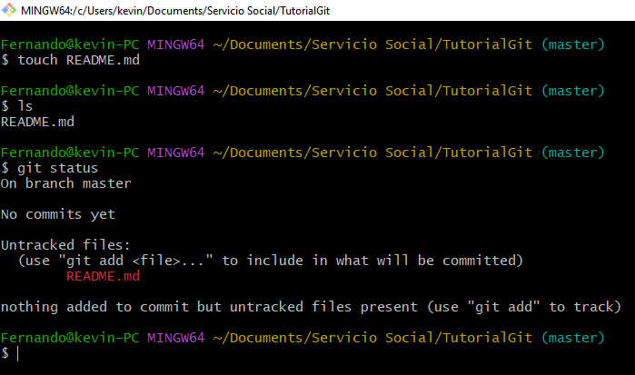

#### `git add`

En este caso nuestro `git status` nos dice que no se ha hecho seguimiento de nuestro archivo README.md, pues este archivo es nuevo en nuestro *working directory*, para hacer el seguimiento a nuestro archivo el primer paso es agregarlo al *staging area* con el comando `git add`.

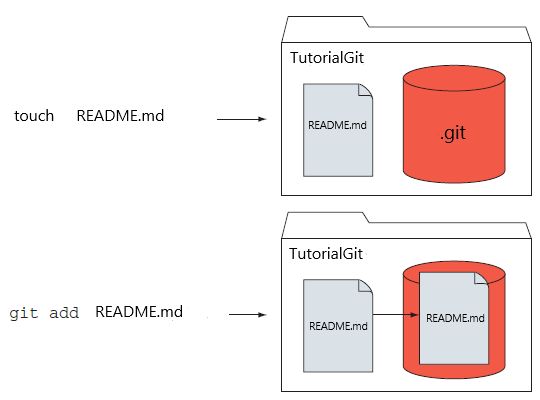

#### `git commit`

Hay que tener claro que agregar el archivo al Staging Area no significa que ya esté dentro del repositorio como parte del historial de versiones. Para esto hace falta hacer un commit, que podemos ver que lo solicita el `git status`.

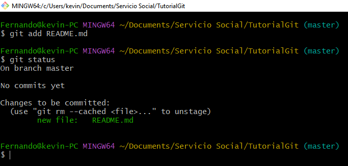

Con `git commit -m`podemos agregar un mensaje descriptivo al commit para saber cuál fue el cambio que guardamos en el historial de versiones de nuestro repositorio. Podemos ver después como `git status` nos dice que ya no hay nada a lo que se le deba hacer commit.

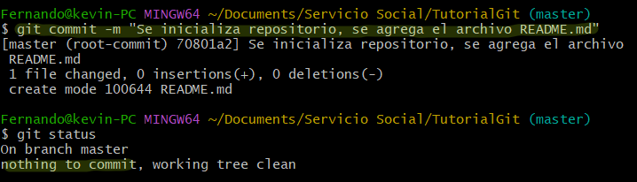

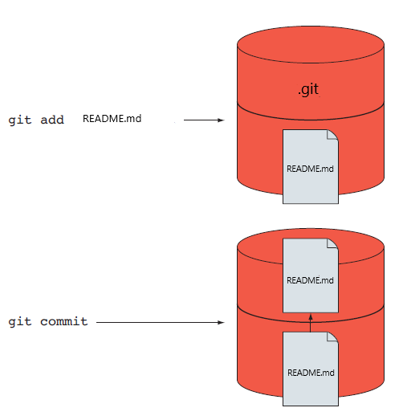

#### `git log`

Con git log podemos listar los commits que hemos creado a lo largo del historial de versiones, en este caso vemos los dos commits que están creados, pero nos muestra quién los hizo, la fecha y el código del commit (que será muy importante en el siguiente apartado)

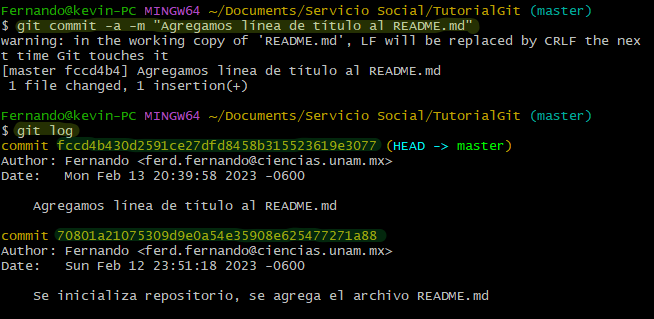

#### `git checkout`

Para poder movernos entre commits usamos checkout y el código del commit, en este caso podemos tener acceso al código con `git log`, sin embargo, para tener una lista más cómoda visualmente de los commits usamos `git log --oneline` que nos oculta los detalles del commit y solo muestra la descripción y parte del código del commit (en azul). Cuando escribimos `git checkout` y agregamos el código del commit entonces nos movemos a esa parte del proyecto donde los siguientes commits aún no existían. Con `git log` podemos ver que sólo tenemos dos commits en ese punto del historial.

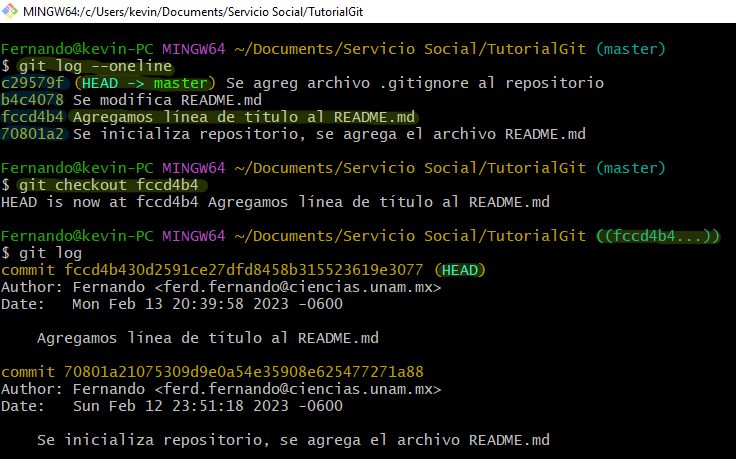

#### `git diff`

Para entender un poco el *Staging Area* vamos a usar el comando `git diff`. Vamos a modificar nuestro README.md agregando las siguientes líneas:

**Es un sistema controlador de versiones *(VCS)*, es decir, registra y da seguimiento a los cambios (y quién los realiza) de los archivos de un proyecto a lo largo del tiempo.**

y lo vamos a agregar al *Staging Area* con `git add`.

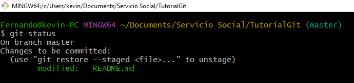

Vamos a modificar de nuevo nuestro README.md porque nos faltó agregar:

**Su importancia radica en que tenemos a nuestra disposición el historial de cambios desde el inicio hasta el estado actual del proyecto.**

Pero este cambio aún no lo vamos a poner el el *Staging Area*.

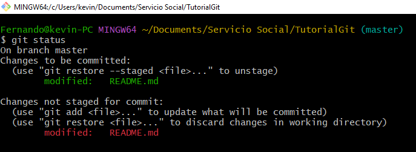

¿Por qué nos aparece que README.md está en el staging area y al mismo tiempo nos aparece que README.md necesita agregarse al staging area? Bueno la respuesta es porque son dos copias del mismo archivo, una en el *Staging Area* y la otra en el *Working Directory* y ambas tienen algo que las diferencia. Aquí es donde entra `git diff`

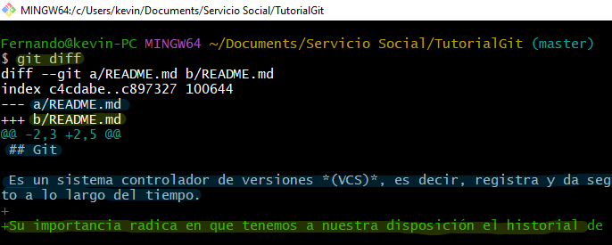

La parte en azul es lo que contine la copia de README.md que agregamos al *Staging Area*, mientras que la parte verde es lo que se agregó a la copia de README.md que está en el *Working Directory*. De esta forma antes de hecer un commit (guardar el cambio dentro del historial de versiones) aún estamos a tiempo de modificar el *Staging Area* agregando los últimos cambios con `git add`.

**Nota**: También podemos ver las diferencias entre los cambios del *Staging Area* y los que ya fueron guardados (commit) en el historial `git diff --staged`

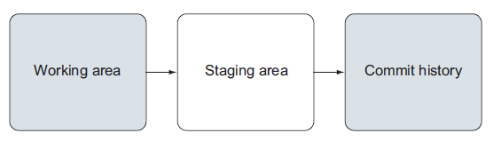

#### `git rm`

En el apartado checkout vemos que tenemos 4 commits, y el más reciente nos dice que agregamos un archivo .gitignore. Si quisieramos borrar este archivo del repositorio lo que tendríamos que hacer es borrarlo con `git rm`

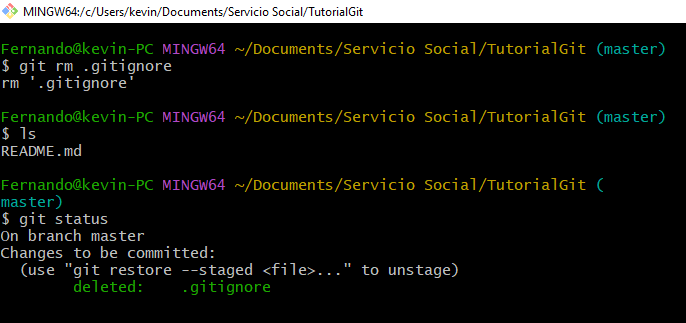

Podemos ver que con `git status` ya se eliminó el archivo y está listo para hacer un commit.

#### `git branch`

- `git branch` Enlista las ramas que hay en el proyecto (con `-a` se muestran las ramas ocultas).
- `git branch name` Crea una nueva rama con el nombre que le asignemos.
- `git branch –D name` Elimina la rama con el nombre que escribamos.
- `git branch –M name` Cambiamos el nombre de la rama en HEAD.
- `git checkout -b name` Se crea una nueva rama y se cambia a esa nueva rama.

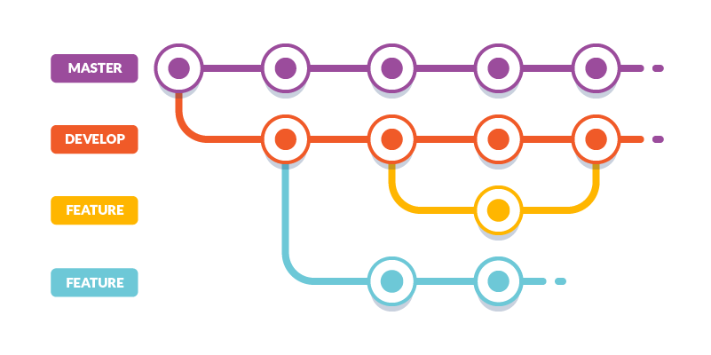

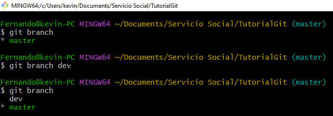

Podemos enlistar todas las ramas en el repositorio con `git branch`, en el primer caso vemos que sólo imprime master en verde. Esto se debe que no hay más ramas y la rama en la que estamos situados es en master. Pero podemos crear una rama para el desarrollo del proyecto, para trabajar sin afectar a la rama principal de su correcto funcionamiento con `git branch nombreRama` en este caso **dev** (development). Al listar las ramas con `git branch` ya podemos ver las dos ramas *master* y *dev* pero el HEAD, es master, así que para cambiar de rama vamos a usar `git checkout`

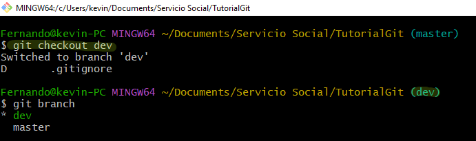

Una vez que nos cambiamos de rama estamos listos para trabajar en nuestro proyecto, modificando, probando nuevas ideas, arreglando errores, etc. Sin afectar la integridad de nuestra rama principal. Con `git branch` verificamos que estamos en la rama *dev* ya que nos la muestra en verde.

Pero cuando ya hemos terminado de trabajar en dev y sabemos que todo está correcto para formar parte del proyecto oficialmente lo que debemos hacer es pasar el desarrollo de la rama *dev* a *master*, la forma de hacerlo es juntando las ramas con `git merge`.